# Textstatistiken und Textähnlichkeiten mit `quanteda`

Philipp Meyer, Institut für Politikwissenschaft

12.05.2021, Textstatistiken und Textähnlichkeiten, Seminar: Quantitative Textanalyse

# 1. Einleitung

In diesem Tutorial behandeln wir Textmetriken und Textvergleiche. [Cornelius Puschmann](http://inhaltsanalyse-mit-r.de/metriken.html) hat zu diesem Thema bereits eine sehr gute Übersicht geliefert. Von daher werde ich seine Erklärungen, seinen Code und seine Darstellungen zu großen Teilen übernehmen und mit eigenen Daten anreichern.

Ihr werdet in diesem Tutorial lernen eure Texte kennenzulernen. Dafür werden wir uns Worthäufigkeiten und die Ähnlichkeit von Texten anschauen. Diese grundlegenden Statistiken sind relevant für die weiterführenden Methoden, die wir im Laufe des Seminars noch näher kennenlernen, und sie helfen uns bereits bei der Beantwortung unserer Fragestellungen. So habe ich in [meiner eigenen Arbeit](https://doi.org/10.1080/10584609.2020.1784329) zum Beispiel die Textähnlichkeit von Pressemitteilungen des Bundesverfassungsgericht und Zeitungsartikeln als abhängige Variable verwendet um die Berichterstattung über Gerichtsentscheidungen zu analysieren.

# 2. Eine Dokument-Feature-Matrix (DFM) erstellen

Die Grundlage für unsere weiteren Schritte bildet die Dokument-Feature-Matrix (DFM) bzw. Dokument-Term-Matrix (DTM).

Hierfür werden wir die Antrittsreden der US Präsidenten aus dem `quanteda`-Paket verwenden (eine Liste aller in `quanteda` gespeicherten Korpora findet ihr hier: quanteda.corpora).

```r
library(quanteda)
library(quanteda.textplots)
library(quanteda.textstats)

inaug_speeches <- data_corpus_inaugural # der Datensatz data_corpus_inaugural kommt aus quanteda und wird automatisch durch den library-Befehl mitgeladen
inaug_speeches
```

```
## Corpus consisting of 59 documents and 4 docvars.
## 1789-Washington :
## "Fellow-Citizens of the Senate and of the House of Representa..."
##
## 1793-Washington :
## "Fellow citizens, I am again called upon by the voice of my c..."
##
## 1797-Adams :
## "When it was first perceived, in early times, that no middle ..."
##
## 1801-Jefferson :
## "Friends and Fellow Citizens: Called upon to undertake the du..."
##
## 1805-Jefferson :
## "Proceeding, fellow citizens, to that qualification which the..."
##
## 1809-Madison :
## "Unwilling to depart from examples of the most revered author..."
##
## [ reached max_ndoc ... 53 more documents ]
```

```r
speeches.stats <- summary(inaug_speeches) # Die einzelnen deskriptiven Metriken des Korpus werden wir später noch gebrauchen können
```

Jetzt erstellen wir eine DTM mittels einer Pipeline:

```r
library(tidyverse)

dtm_speeches <-  inaug_speeches %>%
  tokens(remove_numbers = TRUE, remove_punct = TRUE, remove_symbols = TRUE)  %>%
  tokens_remove(pattern = stopwords("english")) %>%
  tokens_tolower() %>%
  dfm() # wir entfernen alle Füllwörter, Interpunktion, Symbole, Zahlen

dtm_speeches
```

```
## Document-feature matrix of: 59 documents, 9,212 features (92.66% sparse) and 4 docvars.
##                  features
## docs              fellow-citizens senate house representatives among
##   1789-Washington               1      1     2               2     1
##   1793-Washington               0      0     0               0     0
##   1797-Adams                    3      1     0               2     4
##   1801-Jefferson                2      0     0               0     1
##   1805-Jefferson                0      0     0               0     7
##   1809-Madison                  1      0     0               0     0
##                  features
## docs              vicissitudes incident life event filled
##   1789-Washington            1        1    1     2      1
##   1793-Washington            0        0    0     0      0
##   1797-Adams                 0        0    2     0      0
##   1801-Jefferson             0        0    1     0      0
##   1805-Jefferson             0        0    2     0      0
##   1809-Madison               0        0    1     0      1
## [ reached max_ndoc ... 53 more documents, reached max_nfeat ... 9,202 more features ]
```

# 3. Textmetriken

### 3.1 Key-word-in-context

Neben der klassischen Wordcloud lassen sich mit `quanteda` natürlich andere Einblicke in unsere Texte realisieren. Vor allem ist die die KWIC-Methode (Key-Word-In-Context) zu nennen. Hierbei werden der Satzkontext von von euch definierten Begriffe extrahiert und dargestellt.

Mit `quanteda` ist es möglich den Kontext einzeler Wörter oder auch auch ganze Sätze darzustellen. Als ersten Schritt erstellen wir ein `tokens`-Objekt und danach führen wir eine `kwic`-Analyse durch:

```r
inaug_speeches_toks <- tokens(inaug_speeches)

kwic(inaug_speeches_toks, "war", window = 2) # der window befehl definiert die anzahl der kontextwörter die angezeigt werden (ich nehme hier aus darstellerischen gründen nur 2 wörter)
```

```
## Keyword-in-context with 181 matches.
##        [1797-Adams, 191]  the Revolutionary | war | , supplying
##   [1801-Jefferson, 1380]         moments of | war | , till
##    [1805-Jefferson, 558]            time of | war | , if
##    [1805-Jefferson, 569]  sometimes produce | war | , increased
##    [1805-Jefferson, 624]              past. | War | will then
##      [1809-Madison, 401]         nations at | war | by fulfilling
##      [1813-Madison, 136]           that the | war | with a
##      [1813-Madison, 191]         which this | war | is distinguished
##      [1813-Madison, 309]             of the | war | are staked
##      [1813-Madison, 462]             As the | war | was just
##      [1813-Madison, 513]              . The | war | has been
##      [1813-Madison, 561]       prisoners of | war | citizens of
##      [1813-Madison, 577]          usages of | war | . They
##      [1813-Madison, 587]       prisoners of | war | , and
##      [1813-Madison, 628]      and honorable | war | for the
##      [1813-Madison, 879]           the very | war | in which
##      [1813-Madison, 907]             of the | war | on our
##      [1813-Madison, 995]          bring the | war | to an
##     [1813-Madison, 1118]     an unavoidable | war | should have
##     [1813-Madison, 1139]         called for | war | , all
##     [1813-Madison, 1201]         render the | war | short and
##       [1817-Monroe, 750]               all. | War | became at
##      [1817-Monroe, 1326]           the late | war | ? The
##      [1817-Monroe, 1558]        involved in | war | , and
##      [1817-Monroe, 1953]      implements of | war | in a
##      [1817-Monroe, 1966]           event of | war | ; the
##      [1817-Monroe, 2014]            time of | war | , with
##      [1817-Monroe, 2068]      calamities of | war | and to
##      [1817-Monroe, 2073]          bring the | war | to a
##      [1817-Monroe, 2277]       prepared for | war | . With
##      [1817-Monroe, 2559]           event of | war | , unsought
##       [1821-Monroe, 482]        concluded a | war | with a
##       [1821-Monroe, 501]            of that | war | are too
##       [1821-Monroe, 601]             as the | war | had terminated
##      [1821-Monroe, 1013]           ships of | war | . By
##      [1821-Monroe, 1056]           event of | war | our whole
##      [1821-Monroe, 1212]   inseparable from | war | when it
##      [1821-Monroe, 1244]         to prevent | war | . I
##      [1821-Monroe, 1400]              . The | war | between Spain
```

[output cut: 127 more lines]

```
##      [1993-Clinton, 565]          the Civil | War | , to
##      [1997-Clinton, 222]          long cold | war | ; and
##         [2001-Bush, 800]     depression and | war | , when
##        [2009-Obama, 176]              is at | war | , against
##       [2009-Obama, 1708]           of civil | war | and segregation
##        [2013-Obama, 586]          decade of | war | is now
##       [2013-Obama, 1287]  require perpetual | war | . Our
##       [2013-Obama, 1368]           just the | war | ; who
##    [2021-Biden.txt, 363]             and in | war | , we
##    [2021-Biden.txt, 465]           of World | War | II.
##    [2021-Biden.txt, 888]          the Civil | War | , the
##    [2021-Biden.txt, 895]            , World | War | , 9
##   [2021-Biden.txt, 1151]          for total | war | . And
##   [2021-Biden.txt, 1221]          the Civil | War | , when
##   [2021-Biden.txt, 1756]       this uncivil | war | that pits
```

Beachtet bitte das der KWIC-Befehl auf den Korpus und nicht auf die zuvor erstellte DTM angewendet wurde.

Mittels dieser einfachen Methode lassen sich jetzt weitere Analyseschritte realisieren. So können wir zum Beispiel die Häufigkeit und Verteilung von Tokens/Sequenzen berechnen, wie zum Beispiel für die Begriffe "freedom" und "war".

```r
library(dplyr)

term1 <- kwic(inaug_speeches_toks, "freedom") %>%  # KWIC mit dem Wort "freedom"
  as.data.frame() %>%  # Transformation in einen Datensatz
  group_by(docname, keyword) %>% # Gruppierung
  mutate(count = n()) %>% # Berechnung wie oft das Wort "Freedom" vorkommt
  mutate(percentage = count/sum(speeches.stats$Tokens/100), search_term = "freedom") %>%
  arrange(desc(percentage))


term2 <- kwic(inaug_speeches_toks, "war") %>%  # KWIC mit dem Wort "war"
  as.data.frame() %>%  # Transformation in einen Datensatz
  group_by(docname, keyword) %>% # Gruppierung
  mutate(count = n()) %>% # Berechnung wie oft das Wort "war" vorkommt
  mutate(percentage = count/sum(speeches.stats$Tokens/100), search_term = "war") %>%
  arrange(desc(percentage))
```

Ohne Pipeline-Operator würde der Code für z.B. `term1` wie folgt aussehen:

```r
inaug_freedom <- kwic(inaug_speeches_toks, "freedom")

term1 <- as.data.frame(inaug_freedom)
term1 <- group_by(term1, docname, keyword)
term1 <- mutate(term1, count = n()) # Berechnung wie oft das Wort "Freedom" vorkommt
term1 <-  mutate(term1, percentage = count/sum(speeches.stats$Tokens/100), search_term = "freedom")
term1 <- arrange(term1, desc(percentage))
```

So sehen unsere `term1` und `term2 Objekte jetzt aus:

```r
term1
```

```
## # A tibble: 185 x 10
## # Groups:   docname, keyword [42]
##    docname   from    to pre   keyword post  pattern count percentage search_term
##    <chr>    <int> <int> <chr> <chr>   <chr> <fct>   <int>      <dbl> <chr>
##  1 2005-Bu…   135   135 ", A… freedom by s… freedom    23     0.0152 freedom
##  2 2005-Bu…   269   269 "is … freedom . We… freedom    23     0.0152 freedom
##  3 2005-Bu…   315   315 "wor… freedom in a… freedom    23     0.0152 freedom
##  4 2005-Bu…   579   579 "voi… freedom , an… freedom    23     0.0152 freedom
##  5 2005-Bu…   696   696 "is … freedom , wh… freedom    23     0.0152 freedom
##  6 2005-Bu…   804   804 "the… freedom and … freedom    23     0.0152 freedom
##  7 2005-Bu…   843   843 "by … freedom ever… freedom    23     0.0152 freedom
##  8 2005-Bu…   876   876 "Eve… freedom come… freedom    23     0.0152 freedom
##  9 2005-Bu…  1010  1010 ": \… freedom to o… freedom    23     0.0152 freedom
## 10 2005-Bu…  1206  1206 "of … freedom . An… freedom    23     0.0152 freedom
## # … with 175 more rows
```

```r
term2
```

```
## # A tibble: 181 x 10
## # Groups:   docname, keyword [58]
##    docname   from    to pre   keyword post  pattern count percentage search_term
##    <chr>    <int> <int> <chr> <chr>   <chr> <fct>   <int>      <dbl> <chr>
##  1 1821-Mo…   482   482 Unit… war     with… war        16     0.0106 war
##  2 1821-Mo…   501   501 . Th… war     are … war        16     0.0106 war
##  3 1821-Mo…   601   601 . As… war     had … war        16     0.0106 war
##  4 1821-Mo…  1013  1013 be n… war     . By… war        16     0.0106 war
##  5 1821-Mo…  1056  1056 prot… war     our … war        16     0.0106 war
##  6 1821-Mo…  1212  1212 deva… war     when… war        16     0.0106 war
##  7 1821-Mo…  1244  1244 can … war     . I … war        16     0.0106 war
##  8 1821-Mo…  1400  1400 also… war     betw… war        16     0.0106 war
##  9 1821-Mo…  1466  1466 by m… war     in w… war        16     0.0106 war
## 10 1821-Mo…  1669  1669 expo… war     , an… war        16     0.0106 war
## # … with 171 more rows
```

Jetzt können wir die zum Beispiel die absolute Häufigkeit der beiden Begriffe visualisieren:

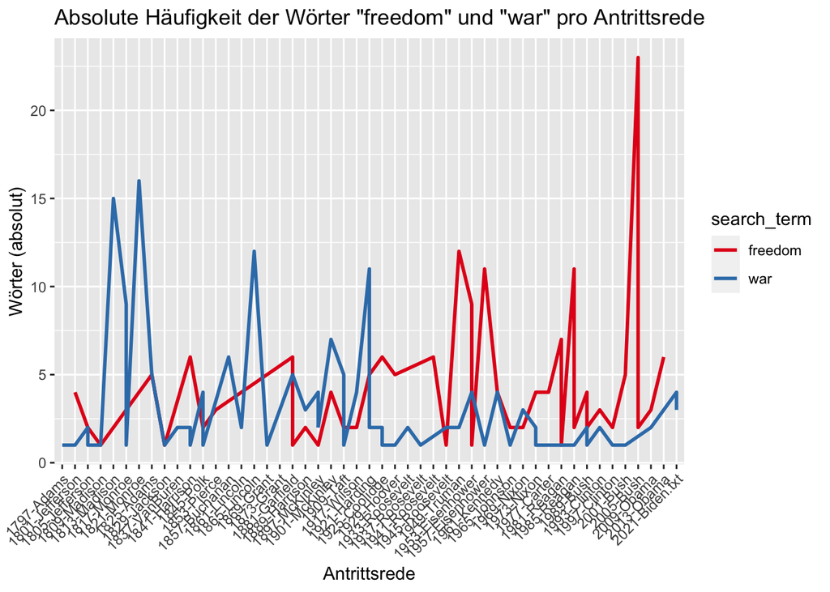

```r
kwic_terms <- bind_rows(term1, term2) # Wir verbinden beide Datensätze miteinander

ggplot(kwic_terms, aes(docname, count, group = search_term, col = search_term)) +
  geom_line(size = 1) +
  scale_colour_brewer(palette = "Set1") +
  theme(axis.text.x = element_text(angle = 45, vjust = 1, hjust = 1)) +
  ggtitle("Absolute Häufigkeit der Wörter \"freedom\" und \"war\" pro Antrittsrede") +
  xlab("Antrittsrede") + ylab("Wörter (absolut)")
```

Neben den Häufigkeiten eines Wortes können wir auch die Position des Wortes in dem jeweiligen Text untersuchen. Dafür stellt `quanteda` die Funktion `textplot_xray` zur Verfügung:

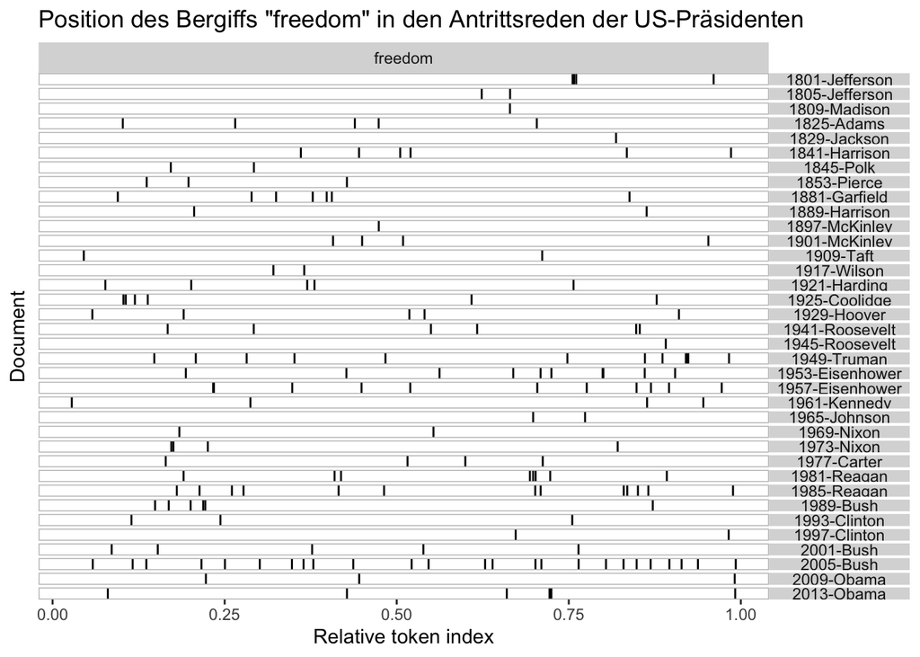

```r
textplot_xray(kwic(inaug_speeches_toks, "freedom")) +
  ggtitle("Position des Bergiffs \"freedom\" in den Antrittsreden der US-Präsidenten")
```

Die x-Achse repräsentiert die Position des jeweiligen Wortes innhalb des Textes. Wie wir sehen hat George W. Bush im Jahr 2005 Freedom nicht nur am Häufigsten von allen Präsidenten verwendet (siehe Plot zur Häufigkeit), sondern auch über seine gesamte Rede hinweg immer mal wieder. Dieses erste deskriptive Ergebnisse könnten wir jetzt im Kontext der 2005 vorherrschenden politischen Entwicklungen (Irakkrieg, großflächige Abhörungen von US-Bürgern etc.) analysieren.

### 3.2 Worthäufigkeiten

Mittels KWIC können wir, sehr umständlich, Worthäufigkeiten für spezielle Wörter untersuchen. Zum Glück bietet `quanteda` mit der `textstat_frequency`-Funktion einen deutlich einfacheren Weg. Anstelle einer umständlichen eigenen Berechnung der verschiedenen Metriken, gibt uns `textstat_frequency` die Metadaten, die Anzahl der Dokumente, in denen das Wort vorkommt und vieles mehr aus:

```r
word_freq <- textstat_frequency(dtm_speeches) # hier nutzen wir die dtm!
head(word_freq)
```

```
##      feature frequency rank docfreq group
## 1     people       584    1      57   all
## 2 government       564    2      52   all
## 3         us       505    3      56   all
## 4        can       487    4      56   all
## 5       must       376    5      52   all
## 6       upon       371    6      47   all
```

Da unser Antrittsredenkorpus die Parteien der Präsidenten enthält, können wir mit `textstat_frequency` die Häufigkeiten nach Parteien gruppieren und mittels `arrange` ordnen:

```r
party_freq <- textstat_frequency(dtm_speeches, groups = Party) %>% arrange(rank, group)
head(party_freq, 35) # schauen wir uns die ersten 35 Beobachtungen an
```

```
##          feature frequency rank docfreq                 group
## 1             us       222    1      21            Democratic
## 5215  government        68    1       6 Democratic-Republican
## 8044      people        20    1       1            Federalist
## 8744         can         9    1       1                  none
## 8745       every         9    1       1                  none
## 8746  government         9    1       2                  none
## 9284      people       264    1      23            Republican
## 15447 government        88    1       3                  Whig
## 2         people       199    2      22            Democratic
## 5216       great        61    2       5 Democratic-Republican
## 8045  government        16    2       1            Federalist
## 9285  government       240    2      23            Republican
## 15448     states        61    2       3                  Whig
## 3            can       173    3      21            Democratic
```

[output cut: 21 more lines]

Die häufigsten Begriffe können wir natürlich auch pro Partei einzeln visualisieren. Der Einfachheit halber werden wir nur die Republikaner und die Demokraten plotten.

Zu erst visualisieren wir die populärsten Begriffe in den Reden republikanischer Präsidenten (+ die Frequenz bei jedem Begriff für die jeweils andere ‘Seite’):

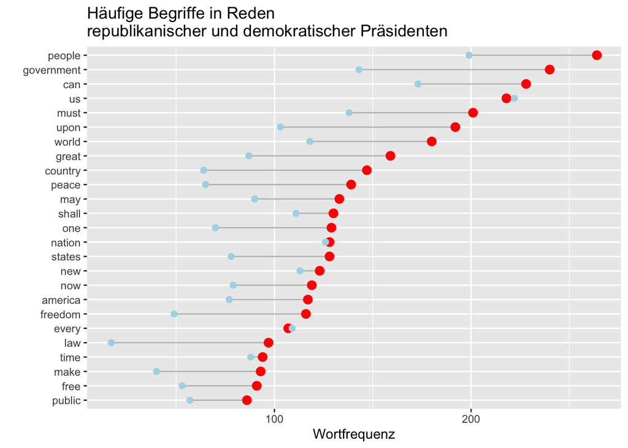

```r
freqs_rep <- filter(party_freq, group == "Republican") %>% as.data.frame() %>% select(feature, frequency)

freqs_dems <- filter(party_freq, group == "Democratic") %>% as.data.frame() %>% select(feature, frequency)

freqs <- left_join(freqs_rep, freqs_dems, by = "feature") %>% head(25) %>% arrange(frequency.x) %>% mutate(feature = factor(feature, feature))

ggplot(freqs) +
  geom_segment(aes(x=feature, xend=feature, y=frequency.x, yend=frequency.y), color="grey") +
  geom_point(aes(x=feature, y=frequency.x), color = "red", size = 3 ) +
  geom_point(aes(x=feature, y=frequency.y), color = "lightblue", size = 2 ) +
  ggtitle("Häufige Begriffe in Reden \nrepublikanischer und demokratischer Präsidenten") +
  xlab("") + ylab("Wortfrequenz") +
  coord_flip()
```

Jetzt visualisieren wir die populärsten Begriffe in den Reden demokratischer Präsidenten (+ die Frequenz bei jedem Begriff für die jeweils andere ‘Seite’):

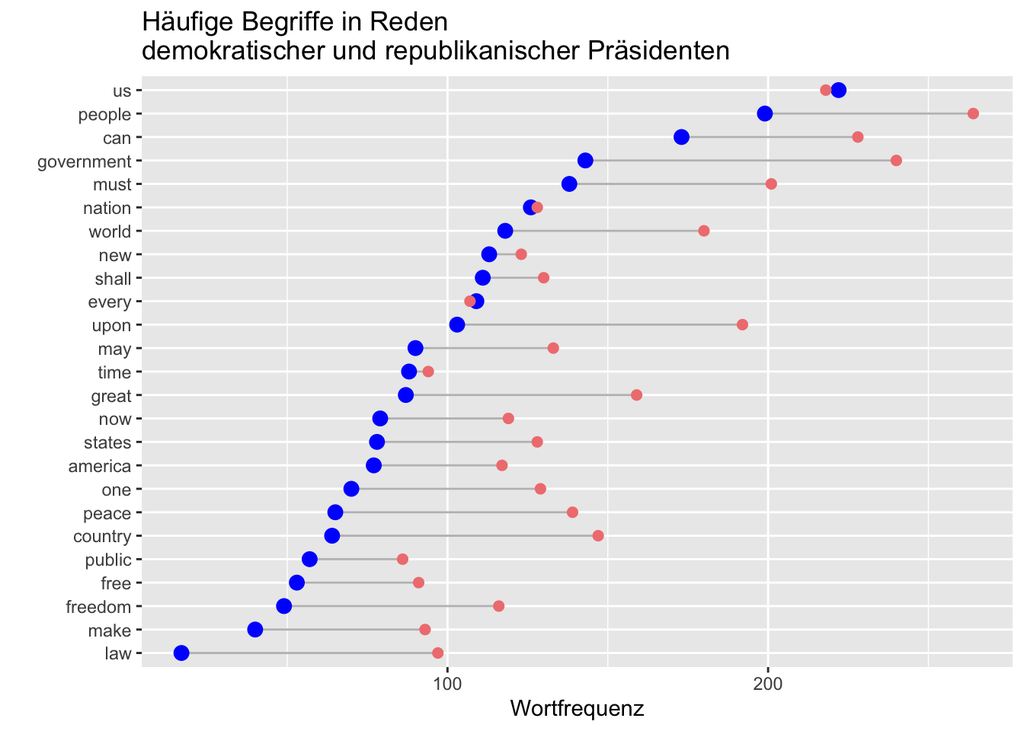

```r
freqs <- left_join(freqs_rep, freqs_dems, by = "feature") %>% head(25) %>% arrange(frequency.y) %>% mutate(feature = factor(feature, feature))

ggplot(freqs) +
  geom_segment(aes(x=feature, xend=feature, y=frequency.y, yend=frequency.x), color="grey") +
  geom_point(aes(x=feature, y=frequency.y), color = "blue", size = 3 ) +
  geom_point(aes(x=feature, y=frequency.x), color = "lightcoral", size = 2 ) +
  ggtitle("Häufige Begriffe in Reden \ndemokratischer und republikanischer Präsidenten") +
  xlab("") + ylab("Wortfrequenz") +
  coord_flip()
```

Natürlich haben wir im Vorhinein nicht sehr viel Arbeit in das Identifizieren von weiteren Stoppwörtern und andere hochfrequente aber eher bedeutungslose Wörter investiert. Wäre das der Fall gewesen, dann hätten wir hier sicherlich noch deutlich aussagekräftigere Ergebnisse erhalten.

# 4. Textähnlichkeiten

### 4.1 Gemeinsam auftretende Wörter

Welche Wörter treten häufig gemeinsam auf? Welche linguistische Nähe oder Distanz haben Texte zueinander? Um diese und weitere Fragen zu beantworten, schauen wir uns jetzt Textähnlichkeiten und weitere Textmetriken an. Hierbei handelt es sich zum Teil um Methoden, welche der Plagiatsprüfung sehr nahe kommen, und auch auch bereits in der Forschung angewendet wurden. Zum Beispiel analysieren [Kaspar Welbers et al.](https://doi.org/10.1080/1461670X.2016.1190663) den Einfluss von Nachrichtenagenturen mittels Textähnlichkeiten.

Schauen wir uns in einem ersten Schritt die Begriffe an, welche häufig gemeinsam auftreten. `quanteda` bietet hierfür die `textstat_collocations`-Funktion, welche wir im folgenden auf unseren Antrittsredenkorpus anwenden.

```r
speeches_collocations <- textstat_collocations(inaug_speeches, min_count = 10) # wir werden unseren korpus (nicht die dtm an!) und definieren das die Begriffs-Nachbarn mindest 10x vorhanden sein müssen
head(arrange(speeches_collocations, desc(count))) # Absteigend nach Aufkommen sortiert
```

```
##      collocation count count_nested length    lambda         z
## 1         of the  1770            0      2 1.5941437 53.247540
## 9         in the   819            0      2 1.7258909 40.115117
## 58        to the   725            0      2 0.9201353 21.889068
## 7         of our   627            0      2 2.1095558 42.195293
## 1049     and the   474            0      2 0.2250432  4.556788
## 2          it is   322            0      2 3.6847316 51.437525
```

```r
head(arrange(speeches_collocations, desc(lambda))) # Absteigend nach Lambda sortiert
```

```
##          collocation count count_nested length    lambda        z
## 278 chief magistrate    10            0      2 10.359152 11.59438
## 271   vice president    18            0      2 10.153434 11.82283
## 98         god bless    16            0      2  9.100153 17.62693
## 173       both sides    13            0      2  8.652016 14.18988
## 93        four years    26            0      2  8.549682 17.89670
## 223             i am    63            0      2  8.266480 12.80124
```

Der Lambda- und z-Wert (z-standardisiertes Lambda) geben die Assoziationsstärke der Begriffspaare an. Je höher der Lambdawert, desto höher ist die Wahrscheinlichkeit, dass die zwei Begriffe auf einander folgen.

Inwiefern ist dieser Wert von der absoluten Häufigkeit eines Wortes (siehe die erste Tabelle) zu differenzieren?

### 4.2 Wortähnlichkeiten

Im Gegensatz zu Textähnlichkeiten (welche wir später behandeln werden), müssen wir bei Wortähnlichkeiten Sätze bzw. Wörter als einzelne Dokumente behandeln. Dadurch können wir auch bei einer geringen Anzahl an Dokumenten zuverlässige Ähnlichkeitsmaße berechnen. Als Methode wählen wir die **Cosine similarity**, die von [Kaspar Welbers et al.](https://doi.org/10.1080/1461670X.2016.1190663) als der aktuelle Standart in den Computational Social Science bezeichnet wird. Cosine similarity hat einen kontinuierlichen Wertebereich von 1 (perfekte Ähnlichkeit/Übereinstimmung) bis 0 (pefekte Ungleichheit/Unähnlichkeit).

Die Berechnung der Wortähnlichkeiten wird durch die `textstat_simil`-Funktion realisiert. Nutzt bitte die help-Funktion (`?textstat_simil` um die weiteren Methoden zur Berechnung von Wort-/Textähnlichkeit kennenzulernen). Als Input für die Funktion erstellen wir eine DFM, in der jeder Satz einer Beobachtung (bzw. "einem Dokument") entspricht. Für unser Beispiel berechnen wir die Wortähnlichkeit zu den Begriffen "freedom" und "war".

```r
sentences_corpus <- corpus_reshape(inaug_speeches, to = "sentences") # wir formen unserem corpus basierend auf den einzelnen Reden in einen corpus basierend auf den einzelnen Sätzen um

sentences_dfm <- sentences_corpus %>%
  tokens(remove_numbers = TRUE, remove_punct = TRUE, remove_symbols = TRUE) %>%
  tokens_remove(pattern = stopwords("english")) %>%
  tokens_tolower() %>%
  dfm()

similarity_freedom <- textstat_simil(sentences_dfm, sentences_dfm[,"freedom"], margin = "features", method = "cosine")

head(similarity_freedom[order(similarity_freedom[,1], decreasing = T),], 10)
```

```
##     freedom    bulwarks      lopped   peaceable  unprovided    regulars
##   1.0000000   0.2065285   0.2065285   0.2065285   0.2065285   0.2065285
##     lightly   burthened    handmaid arraignment
##   0.2065285   0.2065285   0.2065285   0.2065285
```

```r
similarity_war <- textstat_simil(sentences_dfm, sentences_dfm[,"war"], margin = "features", method = "cosine")

head(similarity_war[order(similarity_war[,1], decreasing = T),], 10)
```

```
##         war    retained  calamities       peace termination   prisoners
##   1.0000000   0.1968748   0.1928971   0.1875304   0.1574998   0.1574998
##      saving  deprecated      perish         foe
##   0.1574998   0.1574998   0.1574998   0.1524986
```

Was sehen wir hier? Das Wort mit der höchsten Ähnlichkeit zu "Freedom" ist "bulwarks" also Bollwerke (womöglich interpretierbar mit: "Amerika als Bollwerk des Friedens in der Welt") und das Wort mit der höchstens Ähnlichkeit zu "War" ist "retained" also Rücklage (interpretierbar mit den hohen Geldzahlungen und Schulden die ein Krieg zur Folge hat). Das Wort mit zweithöchsten Ähnlichkeit "calamaties" also Katastrophen macht ebenfalls Sinn. Man muss jedoch sagen, dass wir in Punkt 3.1 dieses Tutorials gesehen haben, dass beide Wörter nicht in jeder Rede ähnlich oft vorkommen.

Wie dem auch sei, auch hier zeigt sich, dass wir zumindest etwas mehr Arbeit in die Identifizierung und Entfernung weiterer unbrauchbarer Wörter hätten stecken müssen (also während des Pre-Processing).

Das Gegenteil zur `textstat_simil`-Funktion ist die `textstat_dist`-Funktion, mit der man die Distanz zwischen Wörtern berechnen kann. Hier hier lässt sich zwischen verschiedenen Distanzmaßen wählen (für mehr Infos wie immer: `?textstat_dist`). In unserem Beispiel nehmen wir die etablierte [euklidische Distanz](https://de.wikipedia.org/wiki/Euklidischer_Abstand) und schauen uns die Ergebnisse für das Wort "freedom" an:

```r
distance_freedom <- textstat_dist(sentences_dfm, sentences_dfm[,"freedom"], margin = "features", method = "euclidean") # wir berechnen die euklidische Distanz

head(distance_freedom[order(distance_freedom[,1], decreasing = T),], 10)
```

```
## government     people         us        can       upon      shall     states
##   29.47881   28.89637   27.74887   27.23968   25.37716   25.23886   25.00000
##       must        may      every
##   24.95997   24.77902   24.06242
```

Der Begriff "Government" ist nach diesem Eregbnis am weitestens von dem Begriff "freedom" entfernt, gefolgt von "people" and "US". Da wir aber von Kapitel 3.2 wissen, dass diese Begriffe auch die häufigsten Begriffe in unserem Korpus sind, ist dieses Ergebnis nicht verwunderlich. In einer Forschungsarbeit müssten wir diese Eregbnisse nutzen um unsere Preprocessing-Schritte verbessern und um damit unsere Eregbnisse zu verbessen.

### 4.3 Textähnlichkeiten

In unseren Beispielen zur Wortähnlichkeit haben wir in den Funktionen den `margins`-Befehl mit "features" also Wörten spezifiziert. Eine weitere Möglichkeit ist die Spezifikation auf "documents", also ganze Dokumente/Texte. Auf diese Weise werden nicht die Ähnlichkeiten von Wörtern oder Sätze verglichen, sondern die Ähnlichkeiten von Dokumenten.

Im folgenden Beispiel inspizieren wir die Ähnlichkeit der 2005er Antrittsrede von George W. Bush mit allen anderen Antrittsreden. Dafür erstellen wir in einem ersten Schritt einen Datensatz mit den Ähnlichkeitsmaßen und im zweiten Schritt visualisieren wir die Maße:

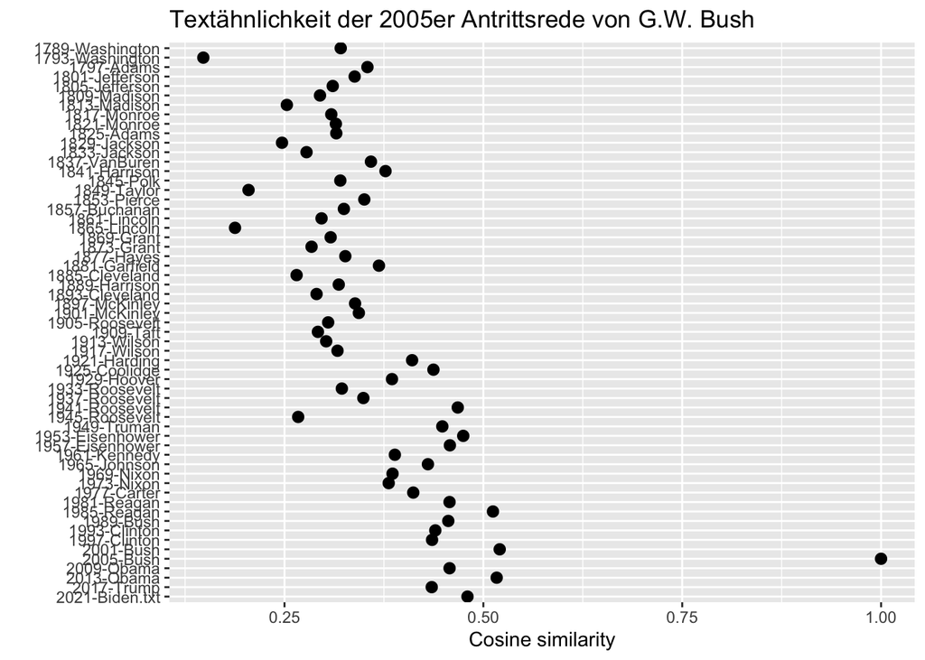

```r
bush_2005_similarity <- data.frame(Text = factor(speeches.stats$Text, levels = rev(speeches.stats$Text)), as.matrix(textstat_simil(dtm_speeches, dtm_speeches["2005-Bush",], margin = "documents", method = "cosine")))

ggplot(bush_2005_similarity, aes(X2005.Bush, Text)) + # Der Variablenname "X2005.Bush" wurde durch unsere Datensatzkreation automatisch gewählt.
  geom_point(size = 2.5) +
  ggtitle("Textähnlichkeit der 2005er Antrittsrede von G.W. Bush") +
  xlab("Cosine similarity") + ylab("")
```

Die "größte" Ähnlichkeit weisen die Reden von Reagan 1985, Bush 2001 und Obama 2013 auf.

Schauen wir uns jetzt beispielhaft die Antrittsrede von Trump aus dem Jahr 2017 an:

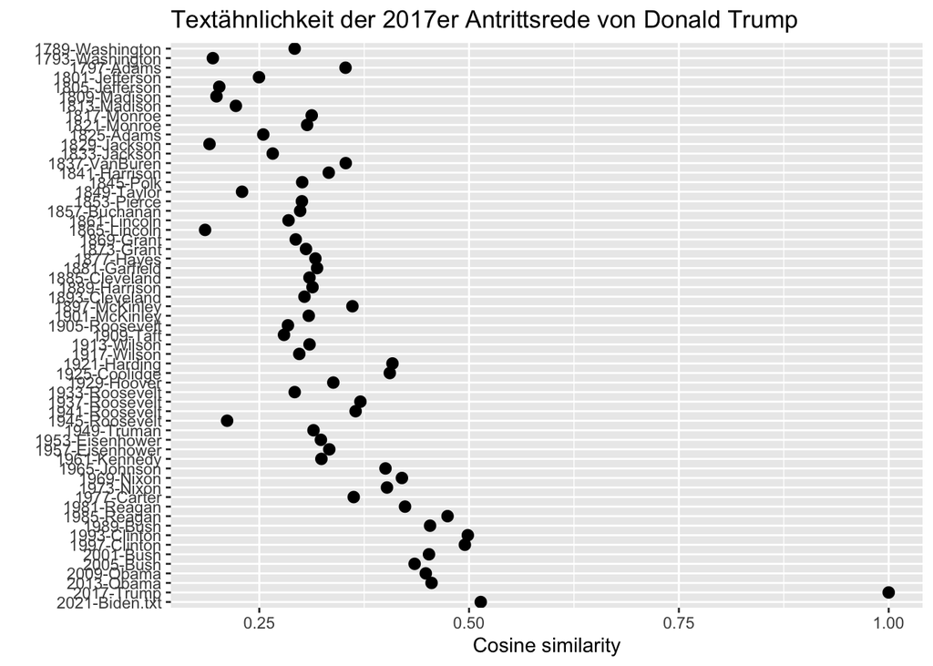

```r
trump_2017_similarity <- data.frame(Text = factor(speeches.stats$Text, levels = rev(speeches.stats$Text)), as.matrix(textstat_simil(dtm_speeches, dtm_speeches["2017-Trump",], margin = "documents", method = "cosine")))

ggplot(trump_2017_similarity, aes(X2017.Trump, Text)) +
  geom_point(size = 2.5) +
  ggtitle("Textähnlichkeit der 2017er Antrittsrede von Donald Trump") +
  xlab("Cosine similarity") + ylab("")
```

Wie ihr sehen könnt, lässt sich mit dieser Art der Darstellung gezielt die Ähnlichkeiten und Unterschiede für einzelne Text visualisieren. Natürlich gibt es noch viele weitere Wege der Visualisierung, wie z.B. Dendogramme oder Heatmaps.

Eine interaktive Heatmap z.B. lässt sich sehr schnell mit der Hilfe der Pakete `heatR` und `d3heatmap` erstellen:

```r
library(d3heatmap)
library(heatR)

textstat_simil(dtm_speeches, margin = "documents", method = "cosine") %>%
  as.matrix() %>%
  heatR::corrheat()
```

[interactive chart not shown]

Am besten ihr probiert selber mal etwas rum und sucht nach eigenen Wegen der Visualisierung von Textähnlichkeiten (ihr könntet euch zum Beispiel das [`RNewsflow`-Paket von Kaspar Welbers](https://cran.r-project.org/web/packages/RNewsflow/vignettes/RNewsflow.html) anschauen).

### 4.4 Keyness

Das Konzept der Keyness wie stark oder schwach ein Begriff in einem Text im Vergleich zum gesamten Korpus vertreten ist. Postive Keynesswerte entsprechen einer Über- und negative Werte einer Unterrepräsentation eines Begriffs in einem Text im Vergleich zum Gesamtkorpus. Die Keyness untersucht also nicht die Position eines Begriffs in einem Text (wie es bei den Ähnlichkeitsmaßen der Fall ist), sondern die Verteilung von Begriffen in Texten.

Mittels der `textstat_keyness`-Funktion untersuchen wir die Keyness-Werte für die 2017er Antrittsrede von Donald Trump und visualisieren sie mit der `textplot_keyness`-Funktion:

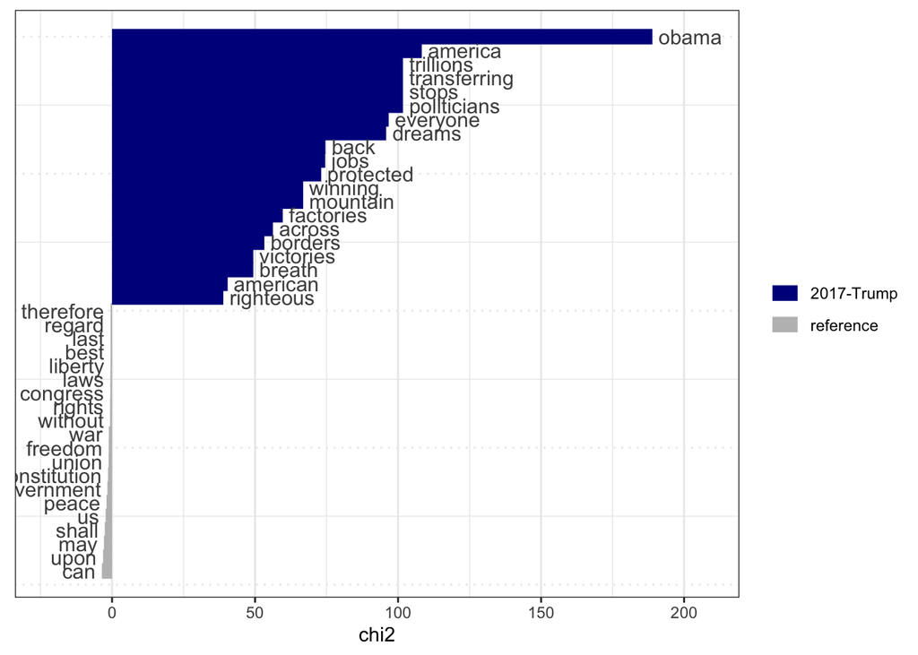

```r
keyness_trump <- textstat_keyness(dtm_speeches, target = "2017-Trump")
textplot_keyness(keyness_trump)
```

Im Vergleich dazu die 2013er Rede von Barack Obama:

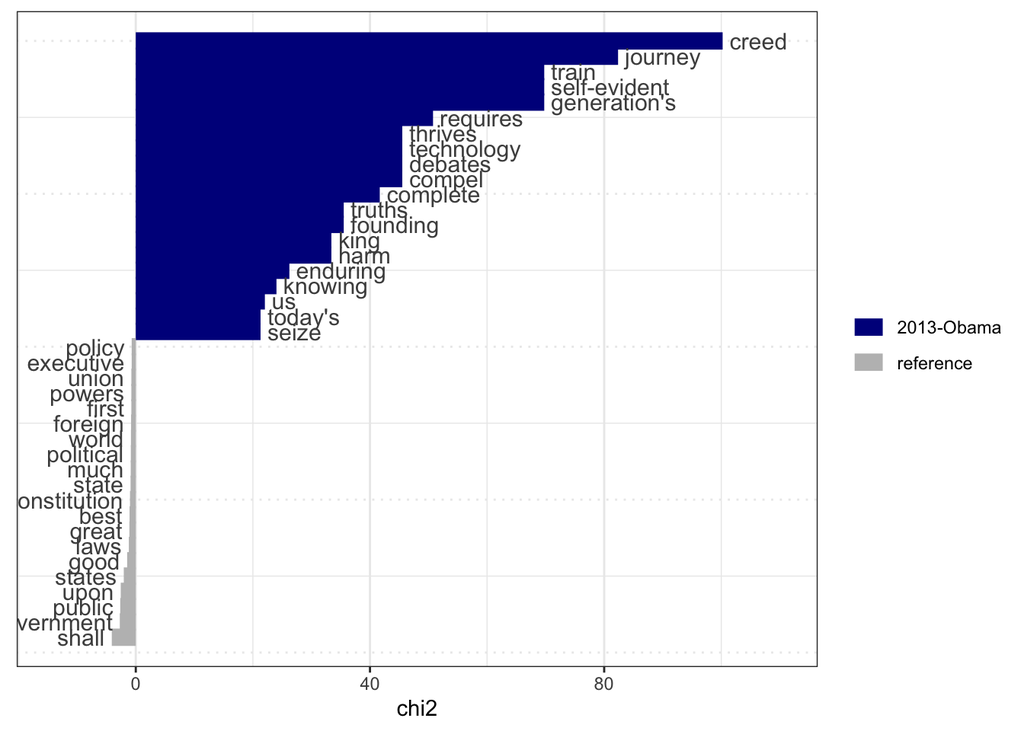

```r
keyness_obama <- textstat_keyness(dtm_speeches, target = "2013-Obama")
textplot_keyness(keyness_obama)
```

Bei diesen beiden Beispielen wird schnell klar, dass sich Trump vor allem an seinem Vorgänger Präsident Obama abgearbeitet hat und dass der Name auch sehr zentral in dieser Rede ist. Während für die Rede von Obama die Begriffe "creed" und "journey" sehr zentral sind. In einer Analyse z.B. wie unterschiedlich die US Präsidenten ihre Antrittsreden framen, wäre eine solche erste deskriptive Einsicht sicherlich sehr hilfreich. Die graue Referenzkategorie zeigt Begriffe an, welche in den anderen Reden auftreten, aber nicht in der von uns untersuchten Rede.

# 5. Lesbarkeit/Komplexität von Texten

### 5.1 Diversität von Texten

Wie lässt sich die Diversität von Texten messen und vergleichen? Haben einige Präsidenten eine geringere Vielfalt an Wörtern genutzt als andere? Stimmt die Annahme, dass Donald Trump eine einfachere Sprache nutzt als seine Amtsvorgänger?

Um diese und andere Fragen zu beantworten, nutzen wir die `textstat_lexdiv`-Funktion von `quanteda`:

```r
speeches_diversity <- textstat_lexdiv(dtm_speeches, measure = "all")
tail(speeches_diversity)
```

```
##          document       TTR         C        R     CTTR        U         S
## 54      2001-Bush 0.6424010 0.9335834 17.97575 12.71078 43.56987 0.9353212
## 55      2005-Bush 0.6176753 0.9306568 19.92900 14.09193 43.51472 0.9349294
## 56     2009-Obama 0.6828645 0.9460250 23.38748 16.53745 56.86513 0.9505226
## 57     2013-Obama 0.6605238 0.9402270 21.20888 14.99694 50.41169 0.9441226
## 58     2017-Trump 0.6409537 0.9322933 17.11478 12.10198 42.13894 0.9331289
## 59 2021-Biden.txt 0.5572316 0.9167855 18.70672 13.22765 36.67539 0.9221331
##           K         I           D         Vm      Maas     lgV0    lgeV0
## 54 32.86635 167.33399 0.002012066 0.03603559 0.1514980 7.538695 17.35849
## 55 32.93405 141.30178 0.002335033 0.04169166 0.1515940 7.674943 17.67221
## 56 23.61314 262.09191 0.001510086 0.03335977 0.1326102 8.959235 20.62940
## 57 29.09796 192.27239 0.001941748 0.03796535 0.1408427 8.319367 19.15605
## 58 41.64298 125.81265 0.002765652 0.04445351 0.1540488 7.353863 16.93290
## 59 37.18520  96.30867 0.002833723 0.04611034 0.1651249 7.005760 16.13136
```

Die `textstat_lexdiv`-Funktion gibt uns eine Vielzahl unterschiedlicher Diversitäts-Metriken aus (`?textstat_lexdiv`). Auf den ersten Blick finden sich auch bereits Unterschiede zwischen den Antrittsreden.

Wollen wir einen etwas genaueren Blick auf die Reden werfen, dann bietet sich eine zum Beispiel Visualisierung anhand der Parteilinien an. Der Einfachheit halber nutzen wir nur eine der viele Metriken.

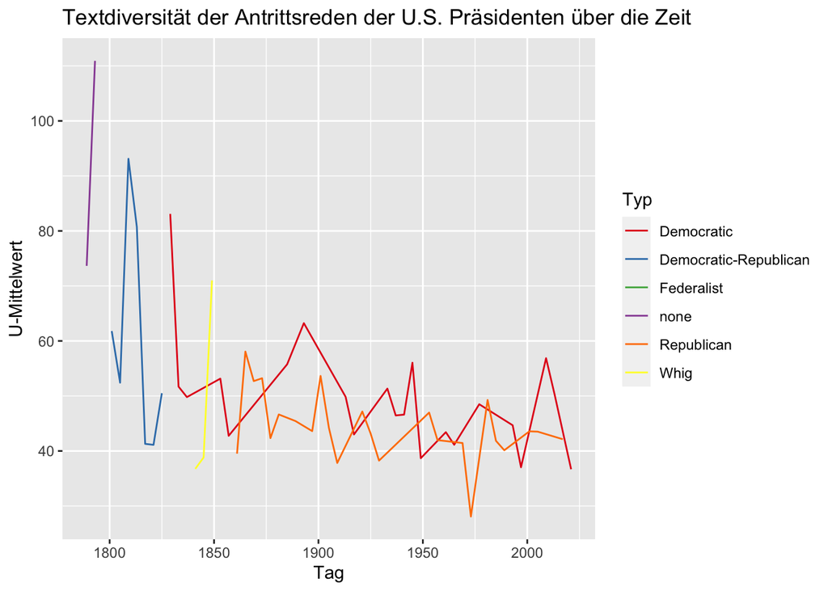

```r
speeches_diversity <- textstat_lexdiv(dtm_speeches, measure = "U")
speeches.U <- left_join(speeches_diversity, speeches.stats, by = c("document" = "Text")) %>%
  group_by(Party, Year) %>%
  summarise(meanU = mean(U))

ggplot(speeches.U, aes(Year, meanU, color = Party)) +
  geom_line() +
  scale_colour_brewer(name = "Typ", palette = "Set1") +
  ggtitle("Textdiversität der Antrittsreden der U.S. Präsidenten über die Zeit") +
  xlab("Tag") + ylab("U-Mittelwert")
```

Wir sehen das die Reden der ersten Präsidenten eine hohe lexikalische Vielfalt aufgewiesen haben. Gerade die beiden Reden von Georg Washington 1789 und 1793 und die Reden von Madison 1809 und 1813 stechen hervor. Wichtig hierbei ist zu wissen, dass die Verwendung von Eigennamen, von Jargon und auch die Textlänge einen Einfluss auf die Textdiversität haben. Umso erstaunlicher ist der Befund für die Reden von Washington, ist doch seine 1789er die kürzeste Rede im gesamten Korpus mit 147 Wörtern und vier Sätzen. Man muss also davon ausgehen, dass er in seiner Rede selten ein Wort wiederholt und viele Fachbegriffe oder Fremdwörter verwendet hat. Das hat sicherlich auch damit zu tun, dass Reden im modernen Medienzeitalter ein ganz anderes und vor allem vielfältigeres Publikum ansprechen müssen.

### 5.2 Textkomplexität

Wie schwierig ist ein Text zu verstehen? Sind Reden von bestimmten Präsidenten einfacher zu verstehen als von anderen? Wie verständlich sind Gerichtsentscheidungen für Rechtslaien?

Diese Fragen lassen sich mit bestimmten Metriken beantworten, welche textuelle Eigenschaften untersuchen. In `quanteda` lassen diese sich recht einfach mit der Funktion `textstat_readability` berechnen. Schauen wir uns die Komplexität der Antrittsreden im Vergleich an:

```r
speeches_readability <- textstat_readability(inaug_speeches, measure = "all")
head(speeches_readability)
```

```
##          document      ARI ARI.simple  ARI.NRI Bormuth.MC Bormuth.GP  Coleman
## 1 1789-Washington 32.95551  106.69538 27.13895 -11.809906 4221063245 43.04266
## 2 1793-Washington 17.77389   76.41667 14.54444  -6.265581  632096054 41.81667
## 3      1797-Adams 32.82940  106.47725 26.85691 -11.905977 4324894954 40.41730
## 4  1801-Jefferson 21.97336   84.81767 17.89308  -7.886374 1259220715 45.51185
## 5  1805-Jefferson 25.49517   91.81200 20.97245  -9.038892 1894675891 43.38102
## 6    1809-Madison 29.51554   99.84711 24.21871 -10.579749 3035921279 42.87370
##   Coleman.C2 Coleman.Liau.ECP Coleman.Liau.grade Coleman.Liau.short Dale.Chall
## 1   37.70898         37.52530           12.78187           12.78320 -3.0285325
## 2   38.61296         43.30799           11.19739           11.19852 18.1939815
## 3   35.32876         39.25280           12.30853           12.30985 -2.9004890
## 4   41.05809         42.77284           11.34402           11.34523 14.3477936
## 5   38.70928         39.93897           12.12051           12.12177  8.0248421
## 6   37.81890         39.33411           12.28625           12.28754 -0.4205207
##   Dale.Chall.old Dale.Chall.PSK Danielson.Bryan Danielson.Bryan.2
```

[output cut: 48 more lines]

Ähnlich der Diversitätsmetriken gibt uns die Funktion wieder eine Vielzahl an unterschiedlichen Messmethoden aus. Schauen wir uns das etwas genauer an und analysieren nur die Antrittsreden von Carter bis Trump. Der Einfachhalb halber nutzen wir auch hier nur eine Messmethode:

```r
corp_subset <- corpus_subset(inaug_speeches, President %in% c("Obama", "Bush", "Trump", "Clinton","Reagan","Carter")) # Wir subsetten unseren Corpus mittels der Nachnamen
ndoc(corp_subset)
```

```
## [1] 11
```

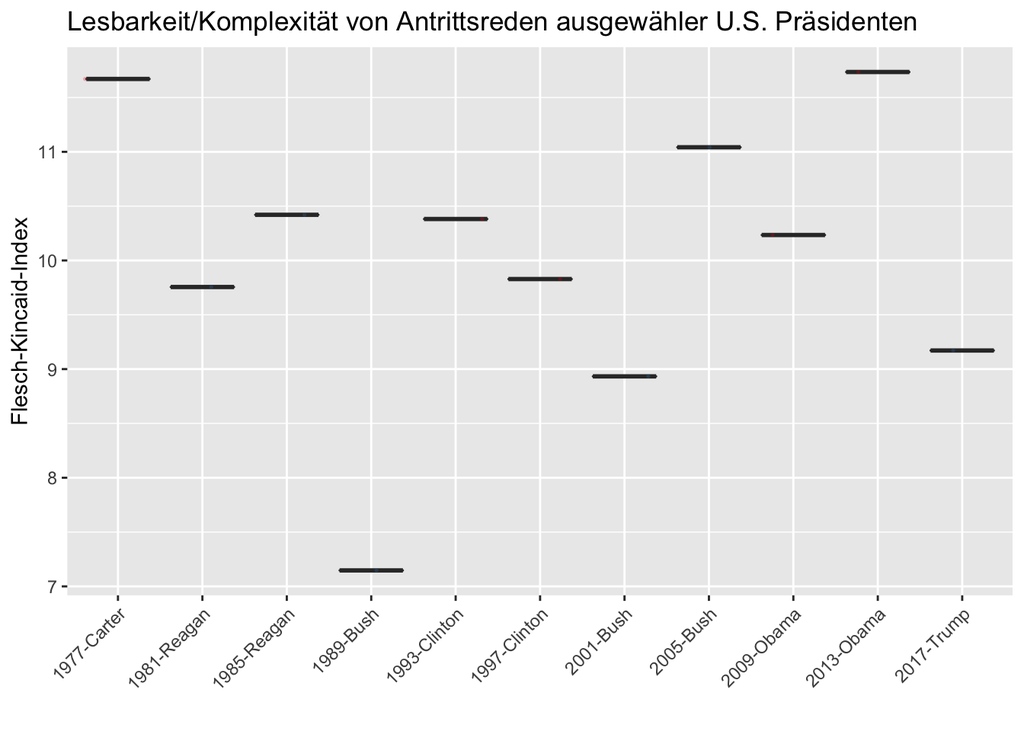

```r
readability <- textstat_readability(corp_subset, measure = "Flesch.Kincaid")
speeches_readability <- left_join(readability, speeches.stats, by = c("document" = "Text"))

ggplot(speeches_readability, aes(document, Flesch.Kincaid)) +
  geom_boxplot() +
  scale_colour_brewer(name = "Typ", palette = "Set1") +
  geom_jitter(aes(document, Flesch.Kincaid, colour = Party), position = position_jitter(width = 0.4, height = 0), alpha = 0.2, size = 0.3, show.legend = F) +
  theme(axis.text.x = element_text(angle = 45, vjust = 1, hjust = 1)) +
  xlab("") + ylab("Flesch-Kincaid-Index") +
  ggtitle("Lesbarkeit/Komplexität von Antrittsreden ausgewähler U.S. Präsidenten")
```

Wir sehen hier, dass die Reden von Carter und Obama 2013 im Vergleich zu den Reden von Bush senior und Donald Trump schwerer verständlich waren. Dieses Bild verhärtet sich, wenn wir uns die Reden aller Präsidenten, visualisiert nach Parteien, anschauen:

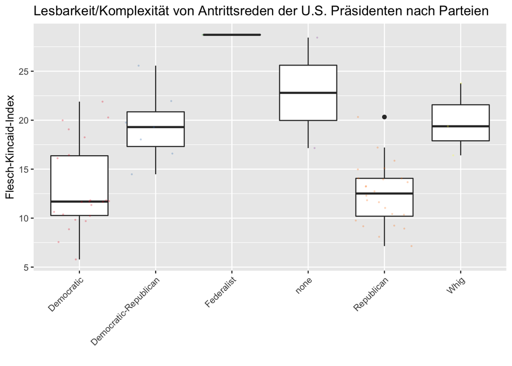

```r
readability <- textstat_readability(inaug_speeches, measure = "Flesch.Kincaid") # wir nutzen hier den gesamten corpus
speeches_readability <- left_join(readability, speeches.stats, by = c("document" = "Text"))

ggplot(speeches_readability, aes(Party, Flesch.Kincaid)) +
  geom_boxplot() +
  scale_colour_brewer(name = "Typ", palette = "Set1") +
  geom_jitter(aes(Party, Flesch.Kincaid, colour = Party), position = position_jitter(width = 0.4, height = 0), alpha = 0.2, size = 0.3, show.legend = F) +
  theme(axis.text.x = element_text(angle = 45, vjust = 1, hjust = 1)) +
  xlab("") + ylab("Flesch-Kincaid-Index") +
  ggtitle("Lesbarkeit/Komplexität von Antrittsreden der U.S. Präsidenten nach Parteien")
```

Wir sehen sehr deutlich, dass die Vertreter der modernen U.S. Parteien (Demokratien, Republikaner) deutlich weniger komplexe Reden gehalten haben als ihre historischen Counterparts. Damit steht dieses Ergebnis im Einklang mit der aktuellen Forschung z.B. von [Benoit et al.](https://onlinelibrary.wiley.com/doi/full/10.1111/ajps.12423). Die Autoren haben anschaulich zeigen können, dass die Wahrscheinlichkeit über Zeit steigt, dass eine "State of the Union Address" eines U.S. Präsidenten einfacher zu verstehen ist als ein grundlegender Text für SchülerInnen in der fünften Klasse.